# Hankinson.pdf

Robert A. Stevens

Wednesday, July 16, 2014

# 1 A non-linear regression: Hankinson’s equation

This example comes from Williams (1959), Example 2.3, page 20, (with adaptations).

For some background information see here:

http://en.wikipedia.org/wiki/Hankinson's_equation

Hankinson’s formula relates the modulus of rupture, fµ, for a timber plank to the angle of stress, µ:

The formula may be “linearized” by taking reciprocals:

but the error structure implied by fitting a simple regression model to this formula may be unrealistic. It may be enough to provide a starting estimate, though.

A more realistic model might be to assume a multiplicative error structure, that is, errors in the measurement of fµ tend to affect the result proportionately rather than additively:

Taking logs converts the error structure to additive, but the parametric form for the regression model remains irreducibly non-linear:

Data from a calibration experiement are given in Table 1, and are available as the data frame hankinson.

```r
setwd("~/GitHub/Venables")
hankinson <- read.csv("hankinson.csv", header = TRUE)
hankinson
```

```
   thetaDeg MRupture
1       0.0    16880
2       2.5    14720
3       5.0    14340
4       7.5    12740
5      10.0    12390
6      15.0     7140
7      20.0     7170
8      30.0     4710
9      45.0     2280
10     60.0     1720
11     90.0      970
```

**Table 1**: Modulus of rupture data for calibration of Hankinson’s formula

```r
hankinson <- within(hankinson, {
  theta <- thetaDeg * base::pi/180
  MRupture <- MRupture/2240 ## change lbs to tons
})
StartM <- lm(1/MRupture ~ 0+I(cos(theta)^2) + I(sin(theta)^2), hankinson)
(f <- structure(1/coef(StartM), names = c("a1", "a2")))
```

```
    a1     a2
9.2648 0.4892
```

We can now fit a non-linear model using these as starting values for the parameters:

```r
NonlinM <- nls(log(MRupture) ~ log(a1) + log(a2) -
               log(a1*sin(theta)^2 + a2*cos(theta)^2), hankinson,
               start = f, trace = FALSE)
summary(NonlinM)
```

```
Formula: log(MRupture) ~ log(a1) + log(a2) - log(a1 * sin(theta)^2 + a2 *
    cos(theta)^2)

Parameters:
   Estimate Std. Error t value Pr(>|t|)
a1   7.0561     0.4527    15.6  8.1e-08 ***
a2   0.5396     0.0352    15.3  9.4e-08 ***
---
Signif. codes:  0 '***' 0.001 '**' 0.01 '*' 0.05 '.' 0.1 ' ' 1

Residual standard error: 0.129 on 9 degrees of freedom

Number of iterations to convergence: 4
Achieved convergence tolerance: 1.01e-07
```

**Table 2**: Coefficient estimates from the non-linear regression

The main output is shown in Table 2.

A generalization of the model allows the power to which the trigonometric terms are raised to be a third parameter, though such refinements are rarely necessary. To check this in the present case, we fit the extended model and test the simpler model as a sub-model of it.

```r
g <- c(coef(NonlinM), p = 0)
NonlinMg <- nls(log(MRupture) ~ log(a1) + log(a2) -
                log(a1*sin(theta)^(2 + p) + a2*cos(theta)^(2 + p)), hankinson,
                start = g)
summary(NonlinMg)
```

```
Formula: log(MRupture) ~ log(a1) + log(a2) - log(a1 * sin(theta)^(2 +
    p) + a2 * cos(theta)^(2 + p))

Parameters:
   Estimate Std. Error t value Pr(>|t|)
a1   6.8181     0.5252   12.98  1.2e-06 ***
a2   0.5158     0.0479   10.78  4.8e-06 ***
p    0.1237     0.1712    0.72     0.49
---
Signif. codes:  0 '***' 0.001 '**' 0.01 '*' 0.05 '.' 0.1 ' ' 1

Residual standard error: 0.133 on 8 degrees of freedom

Number of iterations to convergence: 6
Achieved convergence tolerance: 1.38e-06
```

**Table 3**: Coefficient estimates from the extended non-linear regression

```r
anova(NonlinM, NonlinMg)
```

```
Analysis of Variance Table

Model 1: log(MRupture) ~ log(a1) + log(a2) - log(a1 * sin(theta)^2 + a2 * cos(theta)^2)
Model 2: log(MRupture) ~ log(a1) + log(a2) - log(a1 * sin(theta)^(2 + p) + a2 * cos(theta)^(2 + p))
  Res.Df Res.Sum Sq Df Sum Sq F value Pr(>F)
1      9      0.150
2      8      0.142  1 0.0086    0.49   0.51
```

**Table 4**: Analysis of variance table testing the standard non-linear model, (1), within the extended model, (2)

The main summary results are shown in Table 3 and the analysis of variance results in Table 4.

Now consider predictions from the standard model. First we set up a data frame with the angle µ on a one degree scale. We use the angle in degrees for plotting and the angle in radians for computations.

```r
pHankinson <- within(data.frame(thetaDeg = 0:90),
                     theta <- thetaDeg*base::pi/180)
pHankinson$MRupture <- exp(predict(NonlinM, pHankinson))
```

Note that simply back-transforming the predictions from the log scale gives an estimate of the median modulus of rupture on the natural scale, not the mean.

For standard errors we consider two forms of bootstrap estimates, first the so-called “Bayesian bootstrap”, which re-fits the model using random exponential weights. These are chosen so that the weights have both mean and variance unity:

```r
nr <- nrow(hankinson)
f <- coef(NonlinM) ### update f to the LS estimates; names are OK
Z <- replicate(500, {
  tmpM <- update(NonlinM, weights = rexp(nr), trace = FALSE)
  exp(predict(tmpM, newdata = pHankinson))
})
lims <- apply(Z, 1, quantile, probs = c(1, 39)/40)
pHankinson <- within(pHankinson, {
  lowerBB <- lims[1,] ### NB results taken from the ROWS of lims
  upperBB <- lims[2,]
})
rm(lims, Z)
```

Secondly, consider standard bootstrap estimates, where the model is re-fitted using bootstrap samples of the original data:

```r
bsample <- function(dfr) dfr[sample(nrow(dfr), replace = TRUE), ]
Z <- replicate(500, {
  tmpM <- update(NonlinM, data = bsample(hankinson), trace = FALSE)
  exp(predict(tmpM, newdata = pHankinson))
})
lims <- apply(Z, 1, quantile, probs = c(1, 39)/40)
pHankinson <- within(pHankinson, {
  lower <- lims[1,]
  upper <- lims[2,]
})
rm(lims, Z)
```

Finally we present the results in graphical form:

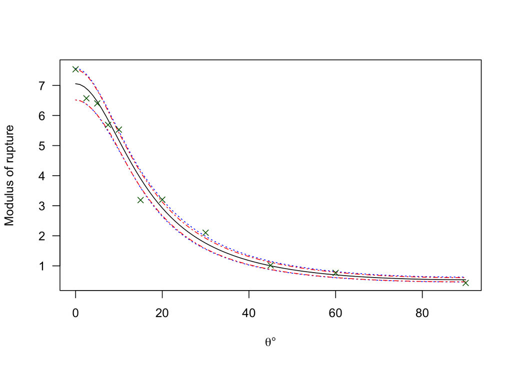

```r
ylim <- with(pHankinson, range(upper, lower, upperBB, lowerBB))
with(pHankinson, {
  plot(thetaDeg, MRupture, type = "l", ylim = ylim, las = 1,
       xlab = expression(theta * degree), ylab = "Modulus of rupture")
  lines(thetaDeg, lower, col="blue", lty = "dotted")
  lines(thetaDeg, upper, col="blue", lty = "dotted")
  lines(thetaDeg, lowerBB, col="red", lty = "dotdash")
  lines(thetaDeg, upperBB, col="red", lty = "dotdash")
  points(MRupture ~ thetaDeg, hankinson, pch = 4, col = "darkgreen")
})
```

**Figure 1**: Estimates of the modulus of rupture, with bootstrap confidence intervals

The result is shown in Figure 1.

Now clean up the global environment:

```r
library(SOAR)
Store(hankinson, pHankinson)
rm(f,g, NonlinM, NonlinMg, StartM, ylim, nr, bsample)
```

# References

Williams, E. J. (1959). Regression Analysis. New York: Wiley.